##The UCR data provides us with our initial variable, Murder and Non Negligent Manslaughter (refererred to as MNNM or homicide). When combined with the TidyCensus data, we can create the variable MNNM_pop, or the “homicide rate,” which is our outcome variable. The homicide rate ranges from 0 to 257.07 homicides per 100,000 people. Since most counties report 0 or very few homicides each year, the median homicide rate is 0. The average homicide rate per 100,000 people is 1.56.

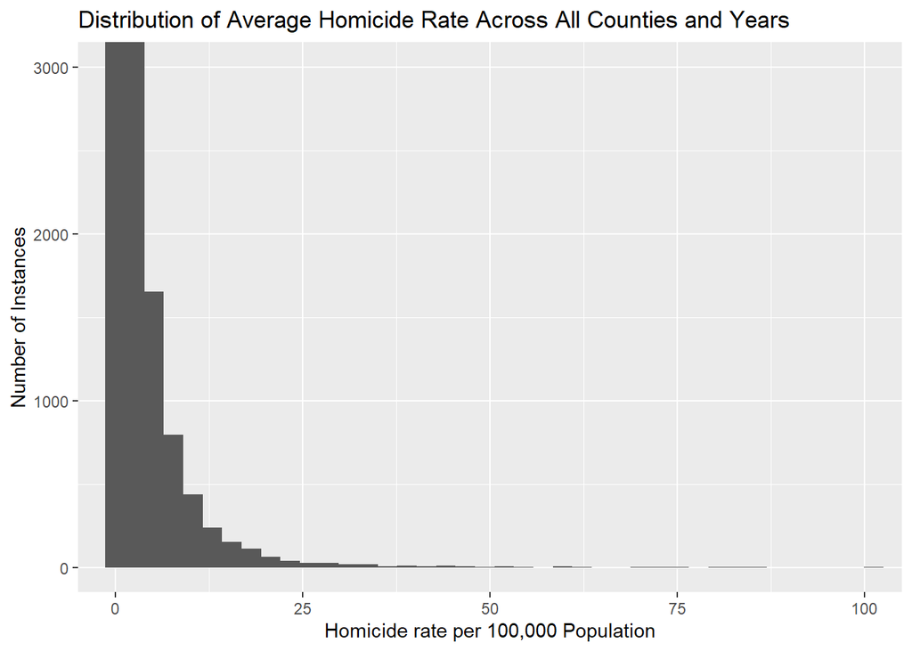

```r
##Histogram of outcome variable
hom_hist<- alldata|>
  ggplot(aes(x=MNNM_pop)) +
  geom_histogram(bins=100) +
  coord_cartesian(xlim = c(0, 100), ylim = c(0, 3000)) +
  labs(title= "Distribution of Average Homicide Rate Across All Counties and Years", x = "Homicide rate per 100,000 Population", y = "Number of Instances" )
hom_hist
```

##For this project, we will be looking at three different explanatory variables: Death penalty (whether or not a state has the death penalty), executions (whether or not a county has executed someone in the past year), and sentences (whether or not a county has sentenced someone in the past year). The death penalty variable is a binary variable of either 0 (indicating a state has abolished the death penalty) or 1 (indicating a state has the death penalty).

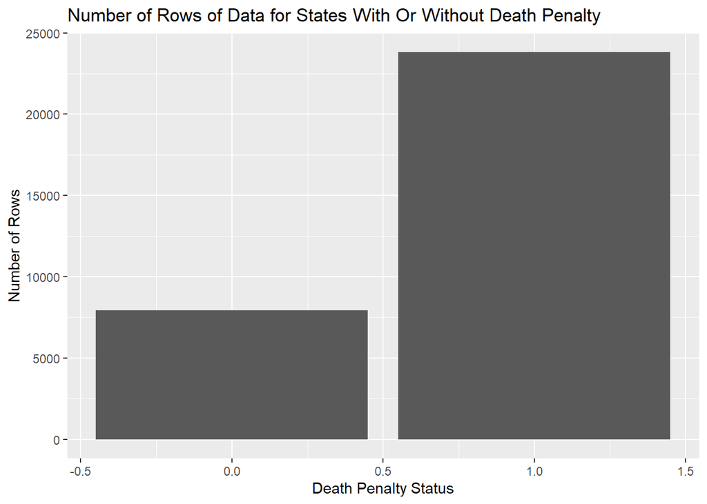

```r
##Histogram of DP variable
alldata|>
  ggplot(aes(x=DP))+
  geom_bar() +
  labs(title= "Number of Rows of Data for States With Or Without Death Penalty", x = "Death Penalty Status", y = "Number of Rows" )
```

##The executions variable ranges from 0-6. There were only 295 instances of counties that executed someone across the whole data set, with almost all of these counties executing only 1 person in a year. However, the executions variable which we will use only has two values: 0, indicating that there were no executions in that year, and 1, indicating that there was at least one execution.

##The sentences variable ranges from 0-13, with 499 instances of counties that sentenced someone to death across the dataset. However, the sentences variable which we will use only has two values: 0, indicating that there were no sentences in that year, and 1, indicating that there was at least one death sentence.

##Analysis: ##To see the relationship between the death penalty and homicide rates, I visualized the relationship with a scatterplot. The graph below plots the death penalty status on the x-axis and the MNNM_rate (homicide rate per 100,000 people) on the y-axis.

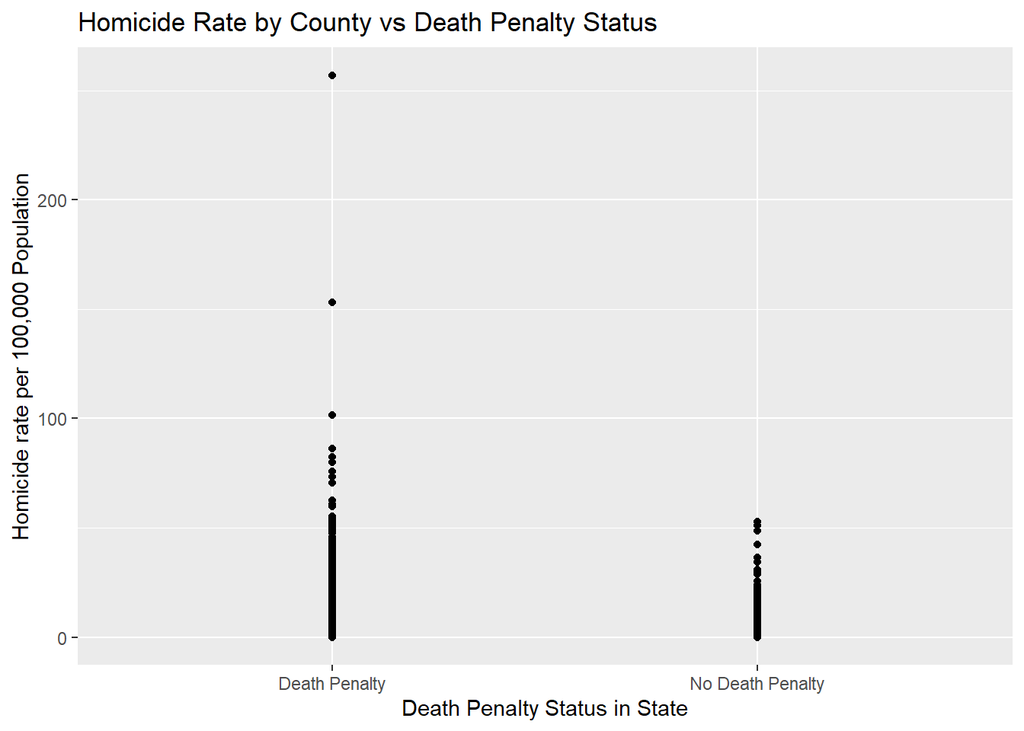

```r
DP_plot<- alldata|>
  mutate(DPYN = if_else(DP == 1, "Death Penalty", "No Death Penalty")) |>
  ggplot(mapping = aes(x=DPYN, y=MNNM_pop, group =DPYN)) +
  geom_point() +
    labs(title= "Homicide Rate by County vs Death Penalty Status", x = "Death Penalty Status in State", y = "Homicide rate per 100,000 Population")
DP_plot
```

##Looking at this plot, there appears to be a positive relationship between a higher homicide rate and a positive death penalty status. Additionally, the graph shows that there are more and larger outliers for counties with the death penalty compared to counties without the death penalty.

##In my next analysis, I calculated the average treatment effect of having the death penalty on a county’s homicide rate, finding that there was an ATE of 1.15. This indicates that having the death penalty is associated with a 1.15 increase in the homicide rate.

```r
ate_dp<- alldata |>
mutate(DPYN = if_else(DP == 1, "DPY", "DPN")) |>
specify(MNNM_pop ~ DPYN) |>
calculate(stat = "diff in means",
order = c("DPY", "DPN"))
ate_dp
```

```
## Response: MNNM_pop (numeric)
## Explanatory: DPYN (factor)
## # A tibble: 1 × 1
##    stat
##   <dbl>
## 1  1.16
```

##I then did a permutation test and calculated the two-sided p-value for the null hypothesis that the true homicide rate is the same across different death penalty statuses. The null distribution of the difference in means is below.

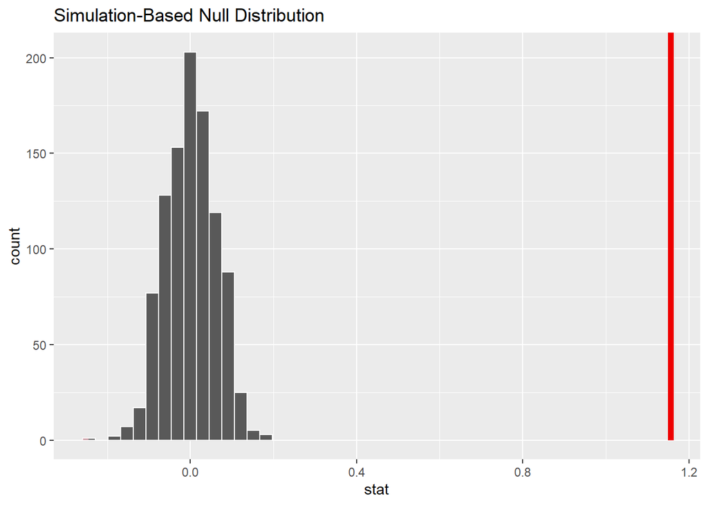

```r
nulldist<- alldata |>
mutate(DPyn = if_else(DP == 1, "DPy", "DPn")) |>
specify(MNNM_pop~ DPyn) |>
hypothesize(null = "independence") |>
generate(reps = 1000,
type = "permute") |>
calculate(stat = "diff in means", order = c("DPy", "DPn"))
nulldist |>
  visualize() +
shade_p_value(obs_stat = ate_dp, direction = "both")
```

```r
get_p_value(nulldist, obs_stat = ate_dp, direction = "both")
```

```
## # A tibble: 1 × 1
##   p_value
##     <dbl>
## 1       0
```

##This distribution represents the distribution of the difference in means when the population is sampled at random 1,000 times. ##Even just looking at this graph, we can see that it is very unlikely that the ATE of death penalty states seen in the data is just due to random change– the red line, which indicates the observed ATE of this data falls far outside the range of any of the average homicide rates found within the 1,000 samples. ##Based on this null distrobution, we calculate the P value to be 0, which means it is statistically significant at a .05 level. Thus, we can reject the null hypothesis that there is no relationship between the death penalty status and homicide rate of a county. In other words, the treatment effect of the death penalty on homicide rate is statistically significant.

##I also performed the same tests (calculating the ATE and performing a permutation test) using whether or not a county had an execution or whether or not a county sentenced someone to death as the explanatory variable.

```r
ate_exs<- alldata |>
mutate(exsyn = if_else(exs > 0, "yes", "no")) |>
specify(MNNM_pop ~ exsyn) |>
calculate(stat = "diff in means",
order = c("yes", "no"))
ate_exs
```

```
## Response: MNNM_pop (numeric)
## Explanatory: exsyn (factor)
## # A tibble: 1 × 1
##    stat
##   <dbl>
## 1 0.134
```

```r
nulldist_exs<- alldata |>
mutate(exsyn = if_else(exs > 0, "yes", "no")) |>
specify(MNNM_pop~ exsyn) |>
hypothesize(null = "independence") |>
generate(reps = 1000,
type = "permute") |>
calculate(stat = "diff in means", order = c("yes", "no"))
nulldist_exs
```

```
## Response: MNNM_pop (numeric)
## Explanatory: exsyn (factor)
## Null Hypothesis: independence
## # A tibble: 1,000 × 2
##    replicate    stat
##        <int>   <dbl>
##  1         1 -0.0804
##  2         2 -0.305
##  3         3  0.131
##  4         4 -0.166
##  5         5  0.101
##  6         6 -0.399
##  7         7 -0.0919
##  8         8  0.129
##  9         9  0.170
## 10        10 -0.112
## # … with 990 more rows
```

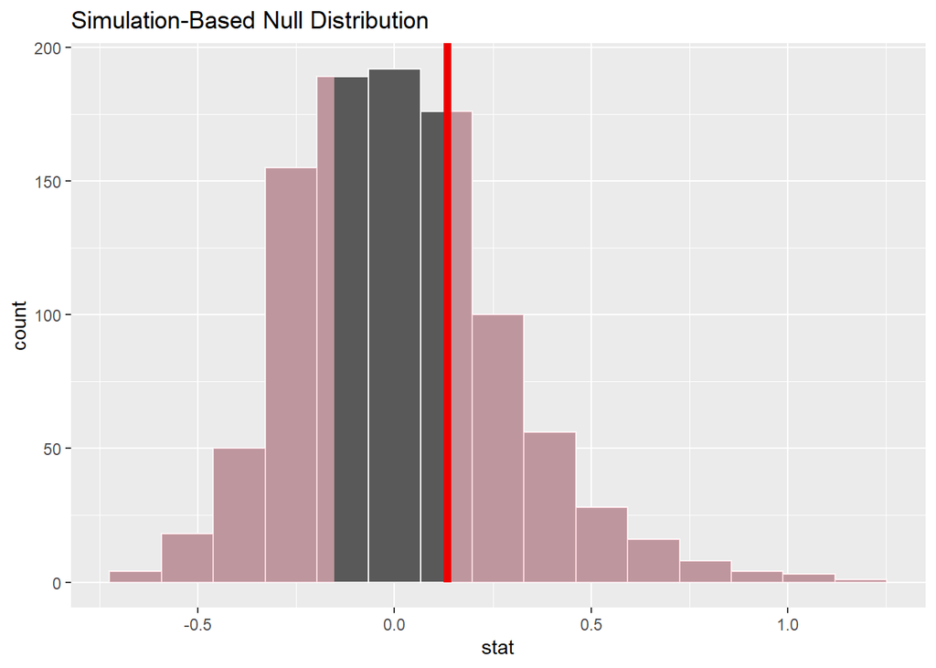

```r
nulldist_exs |>
  visualize() +
shade_p_value(obs_stat = ate_exs, direction = "both")
```

```r
get_p_value(nulldist, obs_stat = ate_exs, direction = "both")
```

```
## # A tibble: 1 × 1
##   p_value
##     <dbl>
## 1   0.016
```

```r
#####

ate_sent<-alldata |>
mutate(sentyn = if_else(sent > 0, "yes", "no")) |>
specify(MNNM_pop ~ sentyn) |>
calculate(stat = "diff in means",
order = c("yes", "no"))
ate_sent
```

```
## Response: MNNM_pop (numeric)
## Explanatory: sentyn (factor)
## # A tibble: 1 × 1
##     stat
##    <dbl>
## 1 -0.300
```

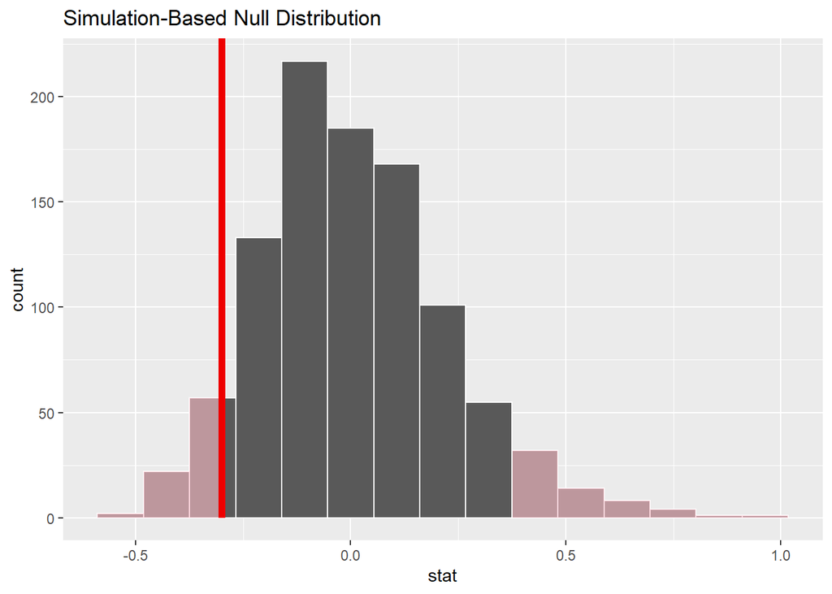

```r
nulldist_sent<- alldata |>
mutate(sentyn = if_else(sent>0, "yes", "no")) |>
specify(MNNM_pop~ sentyn) |>
hypothesize(null = "independence") |>
generate(reps = 1000,
type = "permute") |>
calculate(stat = "diff in means", order = c("yes", "no"))
nulldist_sent |>
  visualize() +
shade_p_value(obs_stat = ate_sent, direction = "both")
```

```r
get_p_value(nulldist, obs_stat = ate_sent, direction = "both")
```

```
## # A tibble: 1 × 1
##   p_value
##     <dbl>
## 1       0
```

```r
nulldist_sent
```

```
## Response: MNNM_pop (numeric)
## Explanatory: sentyn (factor)
## Null Hypothesis: independence
## # A tibble: 1,000 × 2
##    replicate     stat
##        <int>    <dbl>
##  1         1  0.0948
##  2         2 -0.202
##  3         3 -0.00872
##  4         4  0.0623
##  5         5 -0.130
##  6         6  0.0347
##  7         7  0.617
##  8         8  0.0621
##  9         9  0.320
## 10        10 -0.118
## # … with 990 more rows
```

##Regression results: ##In addition to the previous analyses, I performed six regressions on the data– two for each explanatory variable.

##Death penalty regressions: ##The first regression is a bivariate model which regresses the death penalty status on the homicide rate, and the second regression regresses the death penalty status on the homicide rate, but it includes the covariate of violent crime per 100,000 people.

```r
library(broom)
DP_hom_reg_basic<- lm(MNNM_pop~DP, data = alldata)
tidy(DP_hom_reg_basic) |>
knitr::kable(digits = 3)
```

| term | estimate | std.error | statistic | p.value |
| --- | --- | --- | --- | --- |
| (Intercept) | 0.694 | 0.053 | 13.093 | 0 |
| DP | 1.156 | 0.061 | 18.877 | 0 |

```r
DP_hom_reg<- lm(MNNM_pop ~ DP + violent_pop, data = alldata)
tidy(DP_hom_reg) |>
knitr::kable(digits = 3)
```

| term | estimate | std.error | statistic | p.value |
| --- | --- | --- | --- | --- |
| (Intercept) | 0.114 | 0.054 | 2.114 | 0.035 |
| DP | 0.661 | 0.061 | 10.812 | 0.000 |
| violent_pop | 0.010 | 0.000 | 46.528 | 0.000 |

##The bivariate regression suggests that, on average, having the death penalty is associated with a 1.156 increase in homicides per 100,000 people in a county. The multivariable model predicts a weaker, although still significant, association between the death penalty and homicide rates: Holding violent crime rate constant, having the death penalty is associated with a .661 increase in homicides per 100,000 people in a county. ##In both models, the association between the death penalty and homicide rate is statistically sigificant at the test level of alpha = .05. The P value on the coefficent in both models is 0, suggesting there is a near 0% probablility that the association is meaningless and due to random chance. This alligns with the results from the null distrobution graph earlier in the report.

Execution regressions:

```r
ex_reg_base<- lm(MNNM_pop ~ exs , data = alldata)
tidy(ex_reg_base) |>
knitr::kable(digits = 3)
```

| term | estimate | std.error | statistic | p.value |
| --- | --- | --- | --- | --- |
| (Intercept) | 1.559 | 0.027 | 58.048 | 0.000 |
| exs | 0.005 | 0.193 | 0.026 | 0.979 |

```r
ex_reg<- lm(MNNM_pop ~ exs + DP, data = alldata)
tidy(ex_reg) |>
knitr::kable(digits = 3)
```

| term | estimate | std.error | statistic | p.value |
| --- | --- | --- | --- | --- |
| (Intercept) | 0.694 | 0.053 | 13.098 | 0.000 |
| exs | -0.155 | 0.192 | -0.805 | 0.421 |
| DP | 1.158 | 0.061 | 18.894 | 0.000 |

Sentences regression:

```r
sent_reg_base<- lm(MNNM_pop ~ sent , data = alldata)
tidy(sent_reg_base) |>
knitr::kable(digits = 3)
```

| term | estimate | std.error | statistic | p.value |
| --- | --- | --- | --- | --- |
| (Intercept) | 1.562 | 0.027 | 58.149 | 0.000 |
| sent | -0.154 | 0.109 | -1.403 | 0.161 |

```r
sent_reg<- lm(MNNM_pop ~ sent + violent_pop, data = alldata)
tidy(sent_reg) |>
knitr::kable(digits = 3)
```

| term | estimate | std.error | statistic | p.value |
| --- | --- | --- | --- | --- |
| (Intercept) | 0.580 | 0.033 | 17.614 | 0.000 |
| sent | -0.126 | 0.105 | -1.197 | 0.231 |
| violent_pop | 0.010 | 0.000 | 48.911 | 0.000 |

##The first regression is a bivariate model which regresses the variable “sentyn” (whether or not a county sentenced someone to death that year) on the homicide rate, and the second regression regresses “sentyn” on the homicide rate while accounting for the violent crime rate.

##Both regressions suggest that sentencing someone to death is associated with a lower homicide rates. However, the P values of .161 and .23 are still well above the threshhold of .05, meaning these results are not statistically significant.

##Causality and Confounders: ##The results show that there is a statistically significant, positive correlation between a county’s death penalty status and their homicide rate, even when accounting for violent crime rates in those counties. However, there is limited support for the theory that executions or death sentences have any relationship to the homicide rate whether or not you account for violent crime rates. Because the explanatory variable of the death penalty is not randomly assigned as a treatment variable, it cannot be said to causually increase the homicide rate in a county. ##The multivariate regression attempts to control for the possible confounder of violent crime. One of the challenges in this project is that a state with a high homicide rate may choose to keep the death penalt in order to address the problem, which would make it seem as though the death penalty status is correlated with higher homicide rates even though the causality may be in the opposite direction. One way to address this issue is by controlling for violent crime rates. Because violent crime is considered to be strongly related to homicide rate, places with higher violent crime rates would typically have higher homicide rates as well. However, unlike homicide, violent crime is not punished with the death penalty and so the death penalty would not have a deterrant impact on violent crime. Controlling for violent crime can address the problems that typically lead to greater crime (such as economic problems) and allow us to examine the imapcts of the death penalty. For instance, if a state with the death penalty and one without the death penalty both have similar violent crime rates but very different homicide rates, it would indicate that the death penalty has some relationship with the homicide rate. Thus, controlling for the variable of violent crime may help address these issues. ##However, while we may be able to control for violent crime, we cannot control for other possible confounders due to a lack of data: the willingness of county prosecutors to use the death penalty, how frequently life sentences are given in each county, local media coverage of homicides, and a variety of other confounders could influence this data. For example, if a county does not have the death penalty but does give out many life sentences for homicide, this could also be a deterrant to homicide– particularly if life sentences are seen as more common compared to death sentences.

##Additional Analysis: ##My final analysis of the data used a simple difference in means structure to see how homicide rates changed in states which got rid of the death penalty vs states which kept their death penalty status the same over the same period of time. To do this, I looked at four states which eliminated the death penalty in the years covered by my dataset and took the average homicide rates before and after the year of abolition for the state of interest and for all other states. It is worth mentioning that there are 5 states which meet that criteria, but unfortunately New Hampshire did not have sufficient data.

```r
##Illinois
IL_change<- alldata|>
  mutate(pre2011 = if_else(Year < 2011, "Before 2011", "After 2011"), Illinois = if_else(State == 'Illinois', "Illinois", "Other"))|>
  group_by(Illinois, pre2011)|>
  summarize(avg_hom = mean(MNNM_pop, na.rm= TRUE)) |>
  pivot_wider(names_from = pre2011, values_from = avg_hom)|>
  mutate(Change = `Before 2011` - `After 2011`)
IL_change
```

```
## # A tibble: 2 × 4
## # Groups:   Illinois [2]
##   Illinois `After 2011` `Before 2011`  Change
##   <chr>           <dbl>         <dbl>   <dbl>
## 1 Illinois        0.509         0.355 -0.154
## 2 Other           1.58          1.64   0.0578
```

```r
##Maryland
MD_change<- alldata|>
  mutate(pre2013 = if_else(Year < 2013, "Before 2013", "After 2013"), Maryland = if_else(State == 'Maryland', "Maryland", "Other"))|>
  group_by(Maryland, pre2013)|>
  summarize(avg_hom = mean(MNNM_pop, na.rm= TRUE)) |>
  pivot_wider(names_from = pre2013, values_from = avg_hom)|>
  mutate(Change = `Before 2013` - `After 2013`)
MD_change
```

```
## # A tibble: 2 × 4
## # Groups:   Maryland [2]
##   Maryland `After 2013` `Before 2013`    Change
##   <chr>           <dbl>         <dbl>     <dbl>
## 1 Maryland         1.11          1.30  0.196
## 2 Other            1.56          1.56 -0.000374
```

```r
##Delaware
DE_change<- alldata|>
  mutate(pre2016 = if_else(Year < 2016, "Before 2016", "After 2016"), Delaware = if_else(State == 'Delaware', "Delaware", "Other"))|>
  group_by(Delaware, pre2016)|>
  summarize(avg_hom = mean(MNNM_pop, na.rm= TRUE)) |>
  pivot_wider(names_from = pre2016, values_from = avg_hom)|>
  mutate(Change = `Before 2016` - `After 2016`)
DE_change
```

```
## # A tibble: 2 × 4
## # Groups:   Delaware [2]
##   Delaware `After 2016` `Before 2016` Change
##   <chr>           <dbl>         <dbl>  <dbl>
## 1 Delaware         1.66          1.80  0.146
## 2 Other            1.62          1.52 -0.101
```

```r
##Washington
WA_change<- alldata|>
  mutate(pre2018 = if_else(Year < 2018, "Before 2018", "After 2018"), Washington = if_else(State == 'Washington', "Washington", "Other"))|>
  group_by(Washington, pre2018)|>
  summarize(avg_hom = mean(MNNM_pop, na.rm= TRUE)) |>
  pivot_wider(names_from = pre2018, values_from = avg_hom)|>
  mutate(Change = `Before 2018` - `After 2018`)
WA_change
```

```
## # A tibble: 2 × 4
## # Groups:   Washington [2]
##   Washington `After 2018` `Before 2018`  Change
##   <chr>             <dbl>         <dbl>   <dbl>
## 1 Other              1.61          1.55 -0.0583
## 2 Washington         1.41          1.38 -0.0283
```

```r
##Change in counties pre and post abolition for those that sentenced
alldata <- alldata |> mutate(change = if_else(State == "Maryland" | State == "Virginia" | State == "Washington" | State == "New Hampshire" | State == "Connecticut" | State == "Delaware"| State == "Illinois", "Change", "No_change"))
alldata<- alldata |>
  mutate(BEA = (case_when(State == "Illinois" & Year > "2011" ~ "After" ,State == "Maryland" & Year > "2013" ~ "After", State == "Washington" & Year > "2018" ~ "After", State == "Delaware" & Year > "2016" ~ "After", State == "New Hampshire" & Year > "2019" ~ "After", State == "Connecticut" & Year > "2012" ~ "After", State == "Illinois" & Year == "2011" ~ "During", State == "Maryland" & Year == "2013" ~ "During", State == "Delaware" & Year == "2016" ~ "During", State == "Washington" & Year == "2018" ~ "During", State == "New Hampshire" & Year == "2019" ~ "During", State == "Connecticut" & Year == "2011" ~ "During", TRUE ~ "Before")))
alldata|>
  filter(change == "Change") |>
  filter(sent>0) |>
  knitr::kable(digits = 3, caption = "Counties Which Sentenced Someone in States that Eliminated The Death Penalty")
```

Counties Which Sentenced Someone in States that Eliminated The Death Penalty

| State | County | Violent_crime | MNNM | Year | DP | sent | exs | FIPS | estimate | violent_pop | MNNM_pop | change | BEA |
| --- | --- | --- | --- | --- | --- | --- | --- | --- | --- | --- | --- | --- | --- |
| Virginia | Prince William | 662 | 11 | 2009 | 1 | 1 | 2 | 51153 | 360910 | 183.425 | 3.048 | Change | Before |
| Washington | King | 471 | 7 | 2010 | 1 | 1 | 1 | 53033 | 1879189 | 25.064 | 0.373 | Change | Before |
| Virginia | Fairfax | 909 | 11 | 2011 | 1 | 1 | 0 | 51059 | 1064735 | 85.373 | 1.033 | Change | Before |
| Virginia | Wise | 37 | 0 | 2011 | 1 | 1 | 0 | 51195 | 41505 | 89.146 | 0.000 | Change | Before |
| Delaware | New Castle | 1076 | 14 | 2012 | 1 | 1 | 1 | 10003 | 539665 | 199.383 | 2.594 | Change | Before |
| Washington | Pierce | 1000 | 17 | 2012 | 1 | 1 | 0 | 53053 | 798528 | 125.230 | 2.129 | Change | Before |
| Delaware | New Castle | 1008 | 12 | 2015 | 1 | 1 | 0 | 10003 | 549643 | 183.392 | 2.183 | Change | Before |

```r
alldata|>
filter(FIPS == "53033"| FIPS ==  '53053' | FIPS == "10003") |>
  group_by(FIPS, BEA) |>
  summarize(avg_hom = mean(MNNM_pop)) |>
  pivot_wider(names_from = BEA, values_from = avg_hom) |>
  mutate(Change = `Before` - `After`)|>
  select(Before, After, Change, FIPS) |>
   knitr::kable(digits = 3, caption = "Difference in Homicide Rates in Counties Which Sentenced to Death Before and After Abolition")
```

Difference in Homicide Rates in Counties Which Sentenced to Death Before and After Abolition

| Before | After | Change | FIPS |
| --- | --- | --- | --- |
| 1.803 | 1.438 | 0.366 | 10003 |
| 0.298 | 0.339 | -0.041 | 53033 |
| 1.519 | 1.186 | 0.333 | 53053 |

```r
alldata|>
  filter(change == "Change") |>
  filter(exs>0) |>
  knitr::kable(digits = 3, caption = "Counties Which Executed Someone in States that Eliminated The Death Penalty")
```

Counties Which Executed Someone in States that Eliminated The Death Penalty

| State | County | Violent_crime | MNNM | Year | DP | sent | exs | FIPS | estimate | violent_pop | MNNM_pop | change | BEA |
| --- | --- | --- | --- | --- | --- | --- | --- | --- | --- | --- | --- | --- | --- |
| Virginia | Frederick | 95 | 3 | 2009 | 1 | 0 | 1 | 51069 | 72120 | 131.725 | 4.160 | Change | Before |
| Virginia | Prince William | 662 | 11 | 2009 | 1 | 1 | 2 | 51153 | 360910 | 183.425 | 3.048 | Change | Before |
| Virginia | Pittsylvania | 46 | 4 | 2010 | 1 | 0 | 1 | 51143 | 63147 | 72.846 | 6.334 | Change | Before |
| Washington | King | 471 | 7 | 2010 | 1 | 1 | 1 | 53033 | 1879189 | 25.064 | 0.373 | Change | Before |
| Delaware | New Castle | 1122 | 5 | 2011 | 1 | 0 | 1 | 10003 | 536478 | 209.142 | 0.932 | Change | Before |
| Delaware | New Castle | 1076 | 14 | 2012 | 1 | 1 | 1 | 10003 | 539665 | 199.383 | 2.594 | Change | Before |
| Virginia | Wise | 47 | 0 | 2013 | 1 | 0 | 1 | 51195 | 41154 | 114.205 | 0.000 | Change | Before |
| Virginia | Fairfax | 974 | 14 | 2015 | 1 | 0 | 1 | 51059 | 1128722 | 86.292 | 1.240 | Change | Before |
| Virginia | Montgomery | 43 | 2 | 2017 | 1 | 0 | 1 | 51121 | 97692 | 44.016 | 2.047 | Change | Before |

```r
alldata|>
filter(FIPS == "53033"| FIPS ==  '10003') |>
  group_by(FIPS, BEA) |>
  summarize(avg_hom = mean(MNNM_pop)) |>
  pivot_wider(names_from = BEA, values_from = avg_hom) |>
  mutate(Change = `Before` - `After`)|>
  select(Before, After, Change, FIPS) |>
   knitr::kable(digits = 3, caption = "Difference in Homicide Rates in Counties Which Executed Before and After Abolition")
```

Difference in Homicide Rates in Counties Which Executed Before and After Abolition

| Before | After | Change | FIPS |
| --- | --- | --- | --- |
| 1.803 | 1.438 | 0.366 | 10003 |
| 0.298 | 0.339 | -0.041 | 53033 |

##Conclusion: ##Our analysis is limited by having incomplete data from the FBI Database. The first limitation relates to the fact that we lack homicide rate data for all counties. This is because some counties, including those in major population areas like California, fail to report their crime data to the FBI, meaning their information would not be picked up in the UCR records. ##Additionally, the lack of population data going back to 2005 limited the number of states which could be looked at as examples of states which eliminated the death penalty. The TidyCensus package only includes ACS5 data going back to the 2005-2009 survey, meaning that any data before 2009 is inaccessible through this platform. Without population data prior to 2009, 2009 was the earliest year I could calculate the MNNM_pop number for each county. If population data going back to 2005 was available, given that I had UCR data going back to 2005, I could have examined New York, New Jersey, and New Mexico, all states which eliminated their death penalty between 2007-2009. This could have provided more data with which to work, thus leading to a more robust analysis.

##**Next steps:** ##Although I will probably not work on this project going forward, I do hope to use my data analysis skills in future classes. I have really enjoyed gov50 this semester!!!